# ProjectThema9

Jurrien

9/15/2021

Attribute Information:

Thirteen (13) clinical features:

- age: age of the patient (years)
- anaemia: decrease of red blood cells or hemoglobin (yes or no)
- high blood pressure: if the patient has hypertension (yes or no)
- creatinine phosphokinase (CPK): level of the CPK enzyme in the blood (mcg/L)
- diabetes: if the patient has diabetes (boolean)
- ejection fraction: percentage of blood leaving the heart at each contraction (percentage)
- platelets: platelets in the blood (kiloplatelets/mL)
- sex: woman or man (binary)
- serum creatinine: level of serum creatinine in the blood (mg/dL)
- serum sodium: level of serum sodium in the blood (mEq/L)
- smoking: if the patient smokes or not (boolean)
- time: follow-up period (days)
- [target] death event: if the patient deceased during the follow-up period (boolean)

The question this research is aiming to give an answer to is: “Can a death event be predicted when blood ejection fraction and age data is given using machine learning techniques?”

```r
data <- read.csv(file = "heart_failure_clinical_records_dataset.csv")
data$age <- as.integer(data$age)
data <- data[data$age <= 80,]
```

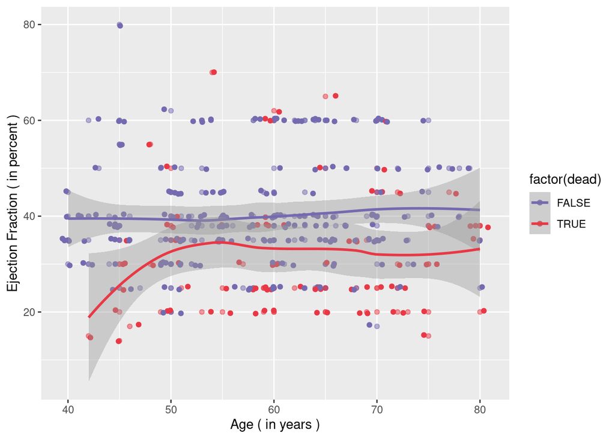

```r
dead <- data$DEATH_EVENT == 1
myColors <- c("#746AB0", "#E83845")

library(ggplot2)
ggplot(data = data, aes(x = age, y = ejection_fraction, colour = factor(dead))) + xlab("Age ( in years )") + ylab("Ejection Fraction ( in percent )") + geom_point(alpha = 0.5) + scale_color_manual(values=myColors) + geom_jitter(width = 1) + geom_smooth()
```